# From College Dropout to Ye: Kanye West’s lyrical evolution.

Irene García-Espantaleón Artal, Jorge Ramos Val and Pablo Romero Medinilla

2025-04-25

# Packages

```r
# List of required packages
required_packages <- c(
  "dplyr", "readr", "ggplot2", "tidyverse", "geniusr", "tidytext",
  "quanteda", "devtools", "forcats", "wordcloud", "RColorBrewer",
  "ggraph", "igraph", "widyr"
)

# Identify which packages are not installed
missing_packages <- required_packages[!(required_packages %in%
                                          installed.packages()[, "Package"])]

# Install missing packages (if any)
if (length(missing_packages) > 0) {
  options(repos = c(CRAN = "https://cloud.r-project.org/"))  # Set CRAN mirror for package installation
  install.packages(missing_packages)
}

# Load all required packages
invisible(lapply(required_packages, library,
                 character.only = TRUE))  # Suppress output while loading packages

# Package descriptions:
# dplyr: Data manipulation with a consistent set of verbs (select, filter, mutate, etc.)
# readr: Fast and friendly functions for reading rectangular data (like CSVs)
# ggplot2: Grammar of graphics-based plotting system
# tidyverse: Collection of R packages for data science (includes ggplot2, dplyr, readr, etc.)
# geniusr: Access lyrics and metadata from the Genius.com API
# tidytext: Text mining using tidy data principles
# quanteda: Framework for managing and analyzing textual data and corpora
# devtools: Tools to simplify package development (often required for installing from GitHub)
# forcats: Tools for working with categorical variables (factors)
# wordcloud: Create word cloud visualizations
# RColorBrewer: Provides color palettes for visualizations
# ggraph: Graph and network visualization using ggplot2 syntax
# igraph: Core functions for creating and analyzing network graphs
# widyr: Compute pairwise correlations and distances between words in tidy data
```

# Introduction

Kanye West, known for his unique style and ability to fuse musical genres, has sparked numerous debates both for his music and his behavior offstage. While on a musical level, he is probably the most influential rapper of the 21st century, on a personal level, he constantly makes controversial statements of all kinds. Recently, he has been at the center of media attention due to controversial remarks and attitudes, including neo-Nazi comments and his contentious treatment of his partners (such as his ex-wifes, Kim Kardashian and Bianca Censori). These situations have raised growing concerns about the potential impact of his persona on society.

Text analysis is a fundamental tool for this purpose, allowing us to extract patterns and insights from large volumes of textual data (in this case, Kanye’s lyrics). To achieve this, three different techniques have been selected:

1. Sentiment Analysis: The objective is to explore the emotions and sentiments expressed in his songs throughout his career, by mapping every lyric token to a sentiment lexicon (NRC, Bing, AFINN) and then aggregating those scores at the album and song level to detect shifts in mood, recurring emotional motifs, and the balance between positive and negative language over time.
2. Insult Analysis: The objective is to identify, quantify and characterize the use of offensive language, such as profanities, slurs and insults, across Kanye’s discography. Using a curated lexicon of “bad words”, we compute the relative frequency of insults per album, track their evolution and examine how spikes in coarse language correlate with overall sentiment and thematic intensity.
3. Word co-occurences. The objective is to build and analyze networks of co‑occurring terms within each line across the lyrics. By treating each word as a node and each co‑occurrence as a weighted edge, we uncover thematic clusters and explore what kind of language is used in each of them.

In addition, tools like Term Frequency and TF-IDF will be used in the introductory part of this exercise to get a general insight of our collection and conduct an exploratory comparison of all the albums comprised.

```r
set.seed(123)
rm(list = ls())
```

# Download the data

```r
# Read the data from GitHub
kanye_west <- read.csv("https://github.com/babyakja/GA_capstone_project/raw/master/data/Kanye%25West.csv")
```

The selected dataframe comes from a GitHub repository containing a total of 98 Kanye West songs, covering his discography from 2004 to 2018. We consider this a long enough period to account for a good part of Kanye’s musical evolution and the personal shifts behind it. However, we’d like to acknowledge that most of the artist’s more controversial turns have happened in the last few years.

It is worth noting that the original CSV file does not include album identification or release years, so this information will need to be added manually to conduct the analysis.

```r
# Create a vector including the songs for each album
album_data <- list(
  "The College Dropout (2004)" = c("We Don't Care", "Graduation Day",
                                   "All Falls Down", "Spaceship",
                                   "Jesus Walks", "Never Let Me Down",
                                   "Get Em High", "Workout Plan",
                                   "The New Workout Plan", "Slow Jamz",
                                   "Breathe In Breathe Out",
                                   "School Spirit", "Lil Jimmy Skit",
                                   "Two Words", "Through the Wire",
                                   "Family Business", "Last Call",
                                   "I'll Fly Away"),

  "Late Registration (2005)" = c("Wake Up Mr. West", "Heard 'Em Say",
                                 "Touch the Sky", "Gold Digger",
                                 "Drive Slow", "My Way Home",
                                 "Crack Music", "Roses", "Bring Me Down",
                                 "Addiction",
                                 "Diamonds From Sierra Leone (Remix)",
                                 "We Major", "Hey Mama", "Celebration",
                                 "Gone", "Late"),

  "Graduation (2007)" = c("Good Morning", "Champion", "Stronger",
                          "I Wonder", "Good Life", "Can't Tell Me Nothing",
                          "Barry Bonds", "Drunk and Hot Girls",
                          "Flashing Lights", "Everything I Am", "The Glory",
                          "Homecoming", "Big Brother"),

  "808s & Heartbreak (2008)" = c("Say You Will", "Welcome To Heartbreak",
                                 "Heartless", "Amazing", "Love Lockdown",
                                 "Paranoid", "RoboCop", "Street Lights", "Bad News",
                                 "See You in My Nightmares", "Coldest Winter"),

  "My Beautiful Dark Twisted Fantasy (2010)" = c("Dark Fantasy", "Gorgeous",
                                                 "Power",
                                                 "All Of The Lights (Interlude)",
                                                 "All of the Lights",
                                                "Monster",
                                                "So Appalled",
                                                "Devil in a New Dress",
                                                "Runaway", "Hell of a Life",
                                                "Blame Game", "Lost in the World",
                                                "Who Will Survive In America"),

  "Yeezus (2013)" = c("On Sight", "Black Skinhead", "I Am a God",
                      "New Slaves", "Blood On The Leaves", "Bound 2"),

  "The Life of Pablo (2016)" = c("Famous", "Feedback", "Low Lights",
                                 "Highlights", "Freestyle 4",
                                 "I Love Kanye", "Wolves",
                                 "Facts (Charlie Heat Version)", "Fade",
                                 "Saint Pablo"),

  "Kids See Ghosts (2018)" = c("Kids See Ghosts",
                               "Freeee (Ghost Town, Pt. 2)",
                               "Fire", "4th Dimension", "Reborn",
                               "Feel the Love", "Cudi Montage"),

  "Ye (2018)" = c("I Thought About Killing You", "Yikes", "All Mine",
                  "Wouldn't Leave", "No Mistakes", "Ghost Town",
                  "Violent Crimes")
)

# Create a new column 'album' in the kanye_west dataset by matching song names to their album
kanye_west$album <- sapply(kanye_west$name, function(x) {
  album_found <- NA  # Initialize album as NA
  for (album in names(album_data)) {
    if (x %in% album_data[[album]]) {
      album_found <- album  # Assign album name if song is found
      break  # Stop searching once the album is found
    }
  }
  return(album_found)
})

# Extract release year from the album string using regular expression
kanye_west <- kanye_west %>%
  mutate(
    release_year = str_extract(album, "\\((\\d{4})\\)") %>%  # Extract the 4-digit year inside parentheses
      str_remove_all("[()]") %>%  # Remove the parentheses
      as.integer()  # Convert to integer
  )

# Convert the dataset to a tibble for better printing and compatibility with tidyverse functions
kanye_west <- as_tibble(kanye_west)

# Define a color palette for each album (used for visualizations)
kanye_colors <- c(
  "The College Dropout (2004)" = "#ec9f1f",
  "Late Registration (2005)" = "#461d0d",
  "Graduation (2007)" = "#b13998",
  "808s & Heartbreak (2008)" = "#eecccc",
  "My Beautiful Dark Twisted Fantasy (2010)" = "#ee2341",
  "Yeezus (2013)" = "#fe0100",
  "The Life of Pablo (2016)" = "#f58c59",
  "Kids See Ghosts (2018)" = "#c2dcd8",
  "Ye (2018)" = "#233d5d"
)

# Define the correct chronological order of Kanye West's albums
album_order <- c(
  "The College Dropout (2004)",
  "Late Registration (2005)",
  "Graduation (2007)",
  "808s & Heartbreak (2008)",
  "My Beautiful Dark Twisted Fantasy (2010)",
  "Yeezus (2013)",
  "The Life of Pablo (2016)",
  "Kids See Ghosts (2018)",
  "Ye (2018)"
)
```

With these additions, we now have the necessary information to carry out the analysis. We can check for missing values to see if all of our rows were filled correctly through this method.

```r
# Check for missing album or release year entries
kanye_west %>%
  filter(is.na(album) | is.na(release_year))
```

```
## # A tibble: 1 × 4
##   name          text                                          album release_year
##   <chr>         <chr>                                         <chr>        <int>
## 1 Lift Yourself "Hard to see, ooh\nThe hang ups we have toda… <NA>            NA
```

```r
head(kanye_west)  # Display the first rows
```

```
## # A tibble: 6 × 4
##   name                        text                            album release_year
##   <chr>                       <chr>                           <chr>        <int>
## 1 Gold Digger                 "[Produced by Kanye West and J… Late…         2005
## 2 Freeee (Ghost Town, Pt. 2)  "[Intro: Marcus Garvey]\nMay I… Kids…         2018
## 3 Kids See Ghosts             "Kids see ghosts sometimes\nKi… Kids…         2018
## 4 I Thought About Killing You "I know, I know, I know, I kno… Ye (…         2018
## 5 Yikes                       "Shit could get menacin', frig… Ye (…         2018
## 6 All Mine                    "Yeah, you supermodel thick, d… Ye (…         2018
```

As observed, there are a total of 9 albums and one song that does not belong to any, meaning it is a single. We don’t know why it was included in the dataset, because it is not the only single released by the artist in this time period. Since we’re interesed in working at the album level, we will drop this observation now:

```r
# Remove rows where the album could not be identified (i.e., NA values)
kanye_west <- kanye_west %>%
  filter(!is.na(album))
```

The next step is to clean the data set: In the text variable, there is extra information that does not correspond to the lyrics but instead includes details about the production or who sings in specific parts of the song (e.g., Intro, Verse 1, etc.). If this information were available for all songs, analyzing the producers or collaborators could provide valuable insights to enrich the study. However, since it is not consistently present across all tracks, it is best to remove it to avoid potential issues.

```r
# Remove the brackets and the information inside
kanye_west$text <- gsub("\\[.*?\\]", "", kanye_west$text)
```

# Tokenization and stopwords:

The lyrics of Kanye West’s songs will be tokenized to make working with words more manageable and structured.

1. Punctuation will be removed, since it does not add value to a text analysis like this.
2. All words will be converted to lowercase to prevent the same words in uppercase and lowercase from being treated as different.

```r
# Tokenization with punctuation removal
kanye_tokens <- kanye_west %>%
  unnest_tokens(word, text, drop = TRUE, strip_punct = TRUE, to_lower = TRUE)
# drop = TRUE to remove the text column

head(kanye_tokens)
```

```
## # A tibble: 6 × 4
##   name        album                    release_year word
##   <chr>       <chr>                           <int> <chr>
## 1 Gold Digger Late Registration (2005)         2005 she
## 2 Gold Digger Late Registration (2005)         2005 take
## 3 Gold Digger Late Registration (2005)         2005 my
## 4 Gold Digger Late Registration (2005)         2005 money
## 5 Gold Digger Late Registration (2005)         2005 when
## 6 Gold Digger Late Registration (2005)         2005 i'm
```

Now, we filter the stopwords (from `tidytext package`) in order to eliminate uninformative words:

```r
# Remove common stop words (e.g., "the", "and") from the tokenized lyrics
kanye_filtered <- kanye_tokens %>%
  anti_join(stop_words)
```

With these steps, we now have our table ready for analysis, ensuring that the data is clean and structured.

# Introductory Analysis

Before delving into the selected techniques, it is necessary to conduct an introductory analysis to better understand the distribution and characteristics of the words present in Kanye West’s lyrics.

```r
# Count the frequency of words
word_counts <- kanye_filtered %>%
  count(word, sort = TRUE)

# top 10 most frequent words
head(word_counts, 10)
```

```
## # A tibble: 10 × 2
##    word       n
##    <chr>  <int>
##  1 la       183
##  2 yeah     176
##  3 shit     158
##  4 love     154
##  5 feel     133
##  6 niggas   121
##  7 nigga    112
##  8 baby     110
##  9 girl     108
## 10 life     107
```

From this table we can already get an idea of the preeminence of swear words, slurs and slang in Kanye’s discography, but we will have to conduct a deeper analysis to get a more accurate picture.

The top word, “la”, doesn’t seem to be very informative, but let’s see it in context to have a better idea:

```r
# Create a text corpus from the 'text' column of the dataset
corpus <- corpus(kanye_west$text)

# Display keyword-in-context (KWIC) for the word "la" with a window of 5 words before and after
kwic(tokens(corpus), "la", window = 5)
```

```
## Keyword-in-context with 178 matches.
##  [text24, 272]            Fuck it," c'est | la | vie" I know that
##  [text36, 368]   that dress from Oscar de | La | Renta, they wouldn’t rent
##  [text46, 348]    , ok You spoiled little | LA | girl You're just an LA
##  [text46, 353]     LA girl You're just an | LA | girl You spoiled little LA
##  [text46, 358] LA girl You spoiled little | LA | girl You're just an LA
##  [text46, 363]     LA girl You're just an | LA | girl You spoiled little LA
##  [text46, 368] LA girl You spoiled little | LA | girl You're just an LA
##  [text46, 373]     LA girl You're just an | LA | girl ( you need to
##  [text46, 386]   now ) You spoiled little | LA | girl You're just an LA
##  [text46, 391]     LA girl You're just an | LA | girl ( you need to
##    [text56, 1]                            | La | , la, la la
##    [text56, 3]                        La, | la | , la la ( Yeah
##    [text56, 5]                    La, la, | la | la ( Yeah ) Wait
##    [text56, 6]                 La, la, la | la | ( Yeah ) Wait'
##  [text56, 154]   forgot where I came from | La | , la, la la
##  [text56, 156]            I came from La, | la | , la la Wait'
##  [text56, 158]               from La, la, | la | la Wait' til I
##  [text56, 159]                 La, la, la | la | Wait' til I get
##  [text56, 168]       I get my money right | La | , la, la la
##  [text56, 170]         my money right La, | la | , la la Then you
##  [text56, 172]              right La, la, | la | la Then you can't tell
##  [text56, 173]                 La, la, la | la | Then you can't tell me
##  [text56, 336]      aight man, holla then | La | , la, la la
##  [text56, 338]           , holla then La, | la | , la la Wait'
##  [text56, 340]               then La, la, | la | la Wait' til I
##  [text56, 341]                 La, la, la | la | Wait' til I get
##  [text56, 350]       I get my money right | La | , la, la la
##  [text56, 352]         my money right La, | la | , la la Then you
##  [text56, 354]              right La, la, | la | la Then you can't tell
##  [text56, 355]                 La, la, la | la | Then you can't tell me
##  [text56, 539]           over you, my God | La | , la, la la
##  [text56, 541]               , my God La, | la | , la la Wait'
##  [text56, 543]                God La, la, | la | la Wait' til I
##  [text56, 544]                 La, la, la | la | Wait' til I get
##  [text56, 553]       I get my money right | La | , la, la la
##  [text56, 555]         my money right La, | la | , la la Then you
##  [text56, 557]              right La, la, | la | la Then you can't tell
##  [text56, 558]                 La, la, la | la | Then you can't tell me
##  [text56, 597]  you can't tell me nothing | La | , la, la la
```

[output cut: 124 more lines]

```
##  [text70, 533]              la lah, la la | la | la la lah ) That's
##  [text70, 534]              lah, la la la | la | la lah ) That's that
##  [text70, 535]              , la la la la | la | lah ) That's that crack
##  [text70, 553]       music, black music ( | La | la la la la la
##  [text70, 554]         , black music ( La | la | la la la la la
##  [text70, 555]        black music ( La la | la | la la la la lah
##  [text70, 556]           music ( La la la | la | la la la lah,
##  [text70, 557]              ( La la la la | la | la la lah, la
##  [text70, 558]             La la la la la | la | la lah, la la
##  [text70, 559]             la la la la la | la | lah, la la la
##  [text70, 562]              la la la lah, | la | la la la la lah
##  [text70, 563]              la la lah, la | la | la la la lah )
##  [text70, 564]              la lah, la la | la | la la lah ) Our
##  [text70, 565]              lah, la la la | la | la lah ) Our Father
##  [text70, 566]              , la la la la | la | lah ) Our Father,
```

The word ‘la’, appears to carry three different meanings in Kanye’s songs: an article in a foreign language, LA (Los Angeles) and, most commonly, a vocable - a wordless sound or syllable with no semantic meaning frequently used in music.

Let’s make a plot and a wordcloud to see this more visually:

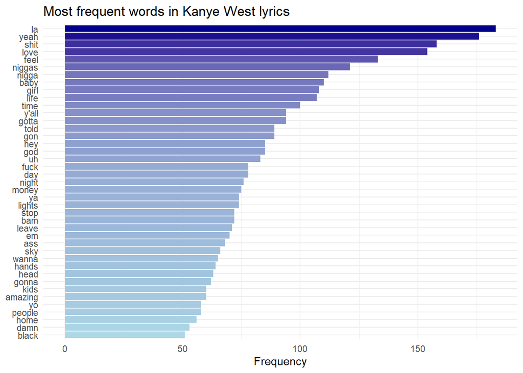

```r
# Visualization of words frequency
word_counts %>%
  filter(n > 50) %>%  # Keep only words that appear more than 50 times
  mutate(word = reorder(word, n)) %>%  # Reorder words by frequency for better plotting
  ggplot(aes(x = word, y = n, fill = n)) +
  geom_bar(stat = "identity", show.legend = FALSE) +  # Bar chart with fill based on frequency
  coord_flip() +  # Flip axes to make labels easier to read
  scale_fill_gradient(low = "lightblue", high = "darkblue") +  # Use gradient fill for bars
  labs(title = "Most frequent words in Kanye West lyrics",
       x = NULL,
       y = "Frequency") +
  theme_minimal()
```

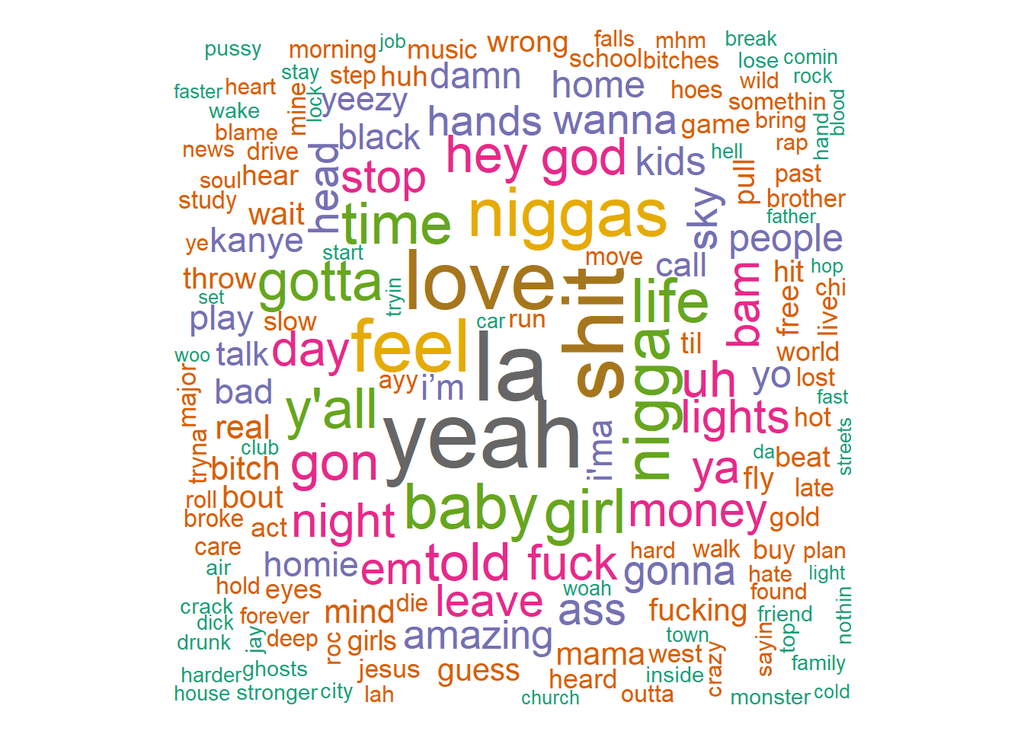

```r
# Generate the wordcloud
wordcloud(words = word_counts$word,
          freq = word_counts$n,
          min.freq = 5,  # Include only words that appear at least 5 times
          max.words = 200,  # Limit total number of words in the cloud
          scale = c(4, 0.5),  # Set word size range
          colors = brewer.pal(8, "Dark2"),  # Use predefined color palette
          random.order = FALSE)  # Words with higher frequency appear in the center
```

Both of these expand on the idea from the previous table: we have some seemingly meaningless syllables, similar to “la”, such as “yeah”, “hey”, “uh” or “bam”, as well as some more examples of swearwords and slang: “fuck”, “ass”, “damn”, “yo”…

We verify the presence of words referring to women, which we could also anticipate: “girl”, “baby”, “mama”, “hoes”, “bitch”…

Some of the words in the graphs, like “time”, “God”, “money” or “kids”, might reveal other topics present in Kanye’s discography; but, in general, we can say that the most common words are pretty ambiguous, and can take on very different meanings depending on the context, for which we will have to take our analysis some steps further.

The following chart shows the 10 most common words per album:

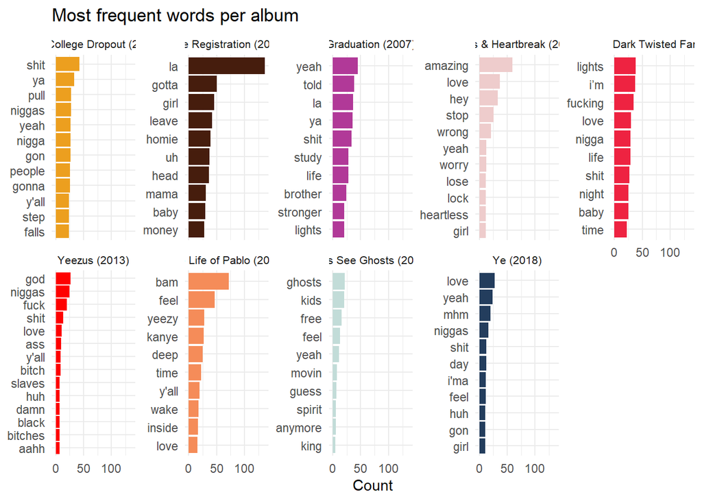

```r
# Visualization: Top 10 most frequent words per album

kanye_filtered %>%
  count(album, release_year, word, sort = TRUE) %>%  # Count word frequency per album
  group_by(album) %>%
  top_n(10, n) %>%  # Select top 10 most frequent words per album
  ungroup() %>%
  mutate(
    album = factor(album, levels = album_order),  # Ensure albums follow a specific order in plots
    word = reorder_within(word, n, album)  # Reorder words within each album for correct facet display
  ) %>%
  ggplot(aes(n, word, fill = album)) +
  geom_col(show.legend = FALSE) +  # Bar chart without legend
  facet_wrap(~ album, scales = "free_y", ncol = 5) +  # One facet per album, free y-scale
  scale_y_reordered() +  # Fixes y-axis label ordering after reorder_within()
  scale_fill_manual(values = kanye_colors) +  # Use custom color palette per album
  labs(title = "Most frequent words per album",
       x = "Count",
       y = NULL) +
  theme_minimal() +
  theme(strip.text = element_text(size = 8))  # Smaller facet labels
```

These plots represent the words that appear most often in each album, regardless of album length, so albums with more or longer songs may dominate with higher raw counts.

As can be seen in the graphs, there are words that appear across several albums by Kanye West, such as “feel”, “girl”, “love”, or “shit”. Most albums don’t have very prominent words, with most words on the top of the ranking having very similar counts.

Next, it’s useful to replicate this plot using *term frequency* instead of word counts. This implies normalizing the count of each word by the total number of words in that album, which is more insightful when comparing across albums of different lengths.

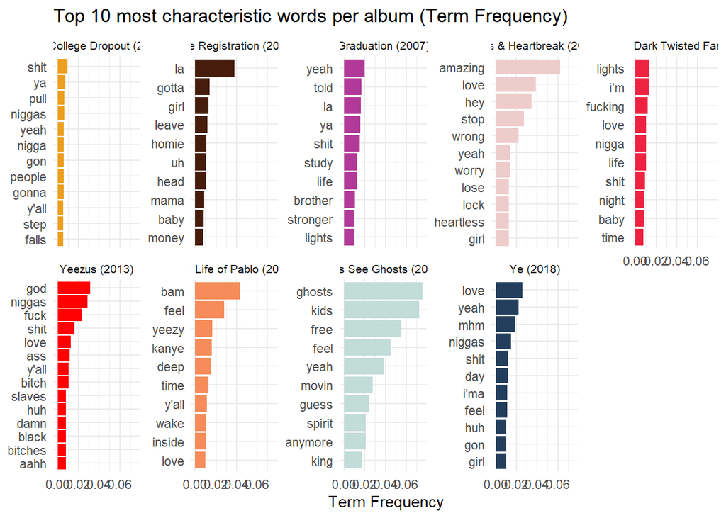

```r
# Visualization: Top 10 most frequent words per album (term)

kanye_filtered %>%
  count(album, release_year, word) %>%  # Count occurrences of each word per album
  group_by(album) %>%
  mutate(
    total_words = sum(n),  # Total number of words in each album
    tf = n / total_words  # Term Frequency: proportion of the word within the album
  ) %>%
  top_n(10, tf) %>%  # Select top 10 words with highest relative frequency per album
  ungroup() %>%
  mutate(
    album = factor(album, levels = album_order),  # Enforce album order for plotting
    word = reorder_within(word, tf, album)  # Reorder words within album facets
  ) %>%
  ggplot(aes(tf, word, fill = album)) +
  geom_col(show.legend = FALSE) +  # Bar chart without legend
  facet_wrap(~ album, scales = "free_y", ncol = 5) +  # One panel per album, independent y-axis
  scale_y_reordered() +  # Fix label ordering in facets
  scale_fill_manual(values = kanye_colors) +  # Use custom album colors
  labs(title = "Top 10 most characteristic words per album (Term Frequency)",
       x = "Term Frequency",
       y = NULL) +
  theme_minimal() +
  theme(strip.text = element_text(size = 8))  # Adjust facet title size
```

For College Dropout and My Dark Twisted Fantasy specially, we can see that the frequency of the top words considering album length is very low, which implies that the vocabulary of those albums is probably more varied and balanced.

On the other hand, the higher TF can be found on Kids See Ghosts, which is likely due to the fact that we only have two songs for this album.

Lastly, we can plot the words with the highest TF-IDF, which will allow us to see what the most distinctive words for each album inside the collection are.

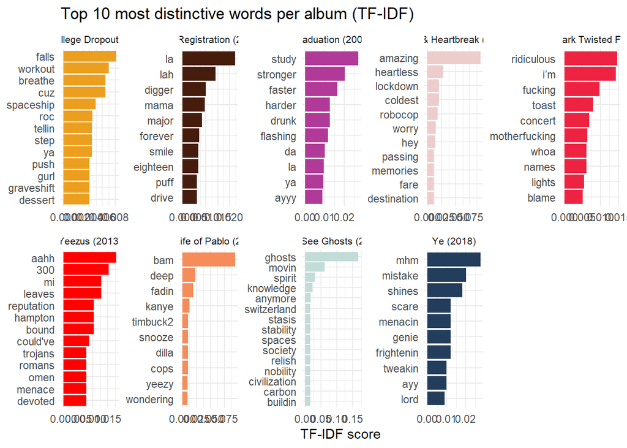

```r
# Visualization: top 10 words per album by TF-IDF

kanye_filtered %>%
  count(album, release_year, word, sort = TRUE) %>%  # Count word occurrences by album
  bind_tf_idf(term = word, document = album, n = n) %>%  # Calculate TF-IDF: identifies words that are important to one album but rare across others
  group_by(album) %>%
  slice_max(tf_idf, n = 10) %>%  # Select top 10 words with highest TF-IDF per album
  ungroup() %>%
  mutate(
    album = factor(album, levels = album_order),  # Ensure album order for plotting
    word = reorder_within(word, tf_idf, album)  # Reorder words within album facet for plotting
  ) %>%
  ggplot(aes(tf_idf, word, fill = album)) +
  geom_col(show.legend = FALSE) +  # Bar chart without legend
  facet_wrap(~ album, scales = "free", ncol = 5) +  # One panel per album, free scales
  scale_y_reordered() +  # Fix label ordering after reorder_within
  scale_fill_manual(values = kanye_colors) +  # Use custom album colors
  labs(
    title = "Top 10 most distinctive words per album (TF-IDF)",
    x = "TF-IDF score",
    y = NULL
  ) +
  theme_minimal() +
  theme(strip.text = element_text(size = 8))  # Smaller facet labels
```

By visualizing the TF-IDF, each album reveals a unique character, giving us a better insight into what distinctive topics Kanye might be covering in each of them. The terms displayed are not only frequently used in the respective albums but are also significant in distinguishing these albums from others.

However, we must bear in mind that, for most bars, TF-IDF scores are pretty low. This may point to a significant vocabulary overlap: Kanye often reuses similar words or themes across all his albums.

Finally, the proportion of each word per album will be calculated, and then the correlation between albums will be analyzed. In this case, two albums will be selected:

```r
# First, calculate word proportions per album
frequency <- kanye_filtered %>%
  count(album, word) %>%  # Count how many times each word appears in each album
  group_by(album) %>%
  mutate(proportion = n / sum(n)) %>%  # Compute relative frequency of each word within the album
  ungroup() %>%
  pivot_wider(
    names_from = album,  # Turn album names into column names
    values_from = proportion,  # Fill these columns with proportion values
    values_fill = 0  # Fill missing combinations with 0 (i.e., word not present in that album)
  )

# Now, compute correlations between selected albums based on word usage patterns

# Correlation between word proportions in "Graduation" and "My Beautiful Dark Twisted Fantasy"
cor.test(data = frequency, ~ `Graduation (2007)` + `My Beautiful Dark Twisted Fantasy (2010)`)
```

```
##
##  Pearson's product-moment correlation
##
## data:  Graduation (2007) and My Beautiful Dark Twisted Fantasy (2010)
## t = -3.5357, df = 6172, p-value = 0.0004097
## alternative hypothesis: true correlation is not equal to 0
## 95 percent confidence interval:
##  -0.06982576 -0.02003692
## sample estimates:
##         cor
## -0.04495926
```

```r
# Correlation between word proportions in "Yeezus" and "Ye"
cor.test(data = frequency, ~ `Yeezus (2013)` + `Ye (2018)`)
```

```
##
##  Pearson's product-moment correlation
##
## data:  Yeezus (2013) and Ye (2018)
## t = -0.1803, df = 6172, p-value = 0.8569
## alternative hypothesis: true correlation is not equal to 0
## 95 percent confidence interval:
##  -0.02723824  0.02265112
## sample estimates:
##         cor
## -0.00229499
```

# 1. Sentiment Analysis

The goal of this analysis is to understand the emotions and tone of Kanye West’s lyrics throughout his discography. To achieve this, we will apply three complementary sentiment analysis approaches:

1.NRC: This allows us to identify specific feelings (joy, sadness, anger, fear, etc.) in his songs, providing a more nuanced view of his lyrics.

2.Bing: To classify words as positive and negative, giving us an overall sense of the sentiment of each album or song.

3.AFINN: To apply a numerical scale to the sentiment of words, allowing us to quantify the overall tone of each song and observe changes in intensity over time.

To carry out the sentiment analysis, we first need to load the lexicons and apply them to our data:

```r
# Load the sentiment lexicons
nrc_lexicon <- get_sentiments("nrc")     # NRC lexicon: includes multiple emotions and positive/negative sentiment
bing_lexicon <- get_sentiments("bing")   # Bing lexicon: classifies words as positive or negative
afinn_lexicon <- get_sentiments("afinn") # AFINN lexicon: assigns numerical sentiment scores (-5 to +5)

# Merge the filtered lyrics with each sentiment lexicon to assign sentiment labels/scores
kanye_nrc <- kanye_filtered %>%
  inner_join(nrc_lexicon, by = "word")  # Only keep words present in the NRC lexicon

kanye_bing <- kanye_filtered %>%
  inner_join(bing_lexicon, by = "word")  # Only keep words present in the Bing lexicon

kanye_afinn <- kanye_filtered %>%
  inner_join(afinn_lexicon, by = "word")  # Only keep words present in the AFINN lexicon
```

### a. NRC

First, it will be useful to explore a little the chosen lexicon, to account for any bias or imbalances that might be reflected on our analysis.

```r
head(nrc_lexicon, n = 10)
```

```
## # A tibble: 10 × 2
##    word        sentiment
##    <chr>       <chr>
##  1 abacus      trust
##  2 abandon     fear
##  3 abandon     negative
##  4 abandon     sadness
##  5 abandoned   anger
##  6 abandoned   fear
##  7 abandoned   negative
##  8 abandoned   sadness
##  9 abandonment anger
## 10 abandonment fear
```

The first important thing we notice is that this is a multilabel classification, where each word might be assigned to more than one emotion. Furthermore, we can see that “negative” is included as a label, which might indicate that this lexicon mixes sentiments and emotions. This is beneficial in that it captures the ambiguity and complexity of language, where most words are nuanced and can take on different meanings and reflect different emotions depending on the context. On the other hand, this could bias our results, since if each word contributes to several emotions, our totals may inflate the apparent emotional content.

We might also check if this lexicon is systematically biased towards a certain sentiment or emotion:

```r
nrc_lexicon %>%
  count(sentiment, sort = TRUE)
```

```
## # A tibble: 10 × 2
##    sentiment        n
##    <chr>        <int>
##  1 negative      3316
##  2 positive      2308
##  3 fear          1474
##  4 anger         1245
##  5 trust         1230
##  6 sadness       1187
##  7 disgust       1056
##  8 anticipation   837
##  9 joy            687
## 10 surprise       532
```

Bearing this in mind will allow us to make a better, more nuanced interpretation of our results.

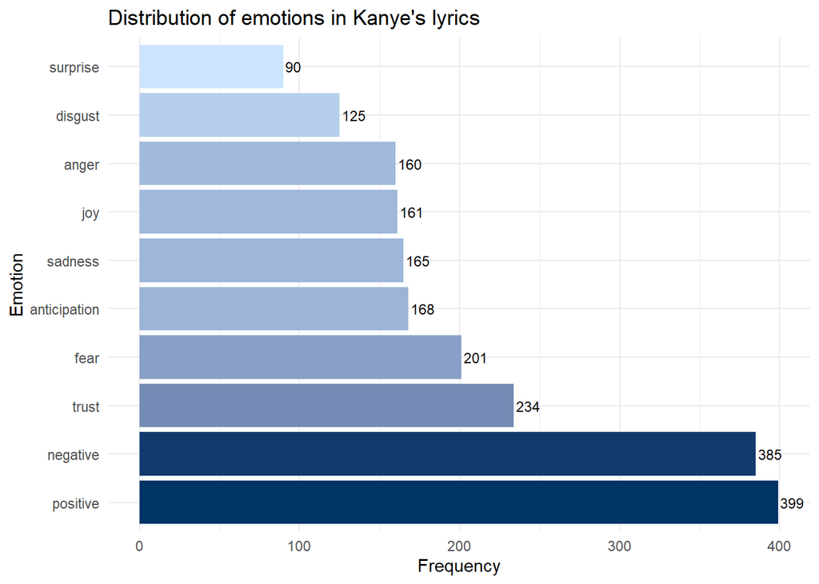

```r
# Count the frequency of each sentiment in the lyrics (NRC lexicon)
kanye_nrc %>%
  distinct(word, sentiment) |> # Keep only unique word-sentiment pairs
  count(sentiment, sort = TRUE) %>%
  mutate(sentiment = factor(sentiment, levels = unique(reorder(sentiment, n)))) %>%  # Order sentiments by frequency
  ggplot(aes(x = sentiment, y = n, fill = n)) +
  geom_col(show.legend = FALSE) +  # Bar chart with no legend
  geom_text(aes(label = n), hjust = -0.1, size = 3) + # Add count labels
   scale_fill_gradient(low = "#cce5ff", high = "#003366") +  # Apply gradient color palette
  coord_flip() +  # Flip axes for horizontal bars
  labs(
    title = "Distribution of emotions in Kanye's lyrics",
    x = "Emotion",
    y = "Frequency"
  ) +
  theme_minimal()
```

As we had anticipated, positive and negative sentiments dominate Kanye’s lyrics, although it is interesting to observe a preeminence of the positive category, seeing that negative words outnumbered positive ones on the original lexicon by around 1000. This becomes more meaningful when we note that trust, a rather positive emotion, is the most frequent in our analysis, though followed closely by a rather negative one, fear. We can also notice a significant balance between anger, joy, sadness and anticipation. This plot considers unique word-sentiment pairs, so only distinct words contribute to sentiments, and not their frequency. We can easily remove one line from our code so that it reflects repeated uses of words:

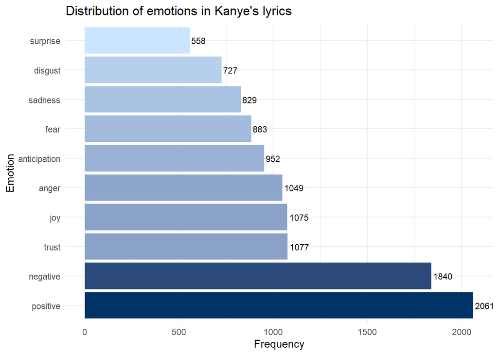

```r
kanye_nrc %>%
  count(sentiment, sort = TRUE) %>%
  mutate(sentiment = factor(sentiment, levels = unique(reorder(sentiment, n)))) %>%
  ggplot(aes(x = sentiment, y = n, fill = n)) +
  geom_col(show.legend = FALSE) +
  geom_text(aes(label = n), hjust = -0.1, size = 3) +
  scale_fill_gradient(low = "#cce5ff", high = "#003366") +
  coord_flip() +
  labs(
    title = "Distribution of emotions in Kanye's lyrics",
    x = "Emotion",
    y = "Frequency"
  ) +
  theme_minimal()
```

In this case, positive words also outnumber negative ones, but the gap between these sentiment categories and the rest of emotions is widened, suggesting that Kanye commonly uses words that have some sentiment but no emotion assigned (maybe generic language). Trust remains the most frequent emotion, and joy’s rank goes up. This suggests that Kanye doesn’t employ a very varied vocabulary to express joy, but rather reuses joyful words in his lyrics. The same thing happens to words expressing anger. On the other hand, fear and sadness as emotions notably drop in the ranking, indicating that Kanye has a richer vocabulary to convey these emotions, but he doesn’t use it as frequently.

For a deeper analysis, the following graph shows the 4 most frequent emotions in the lyrics by album:

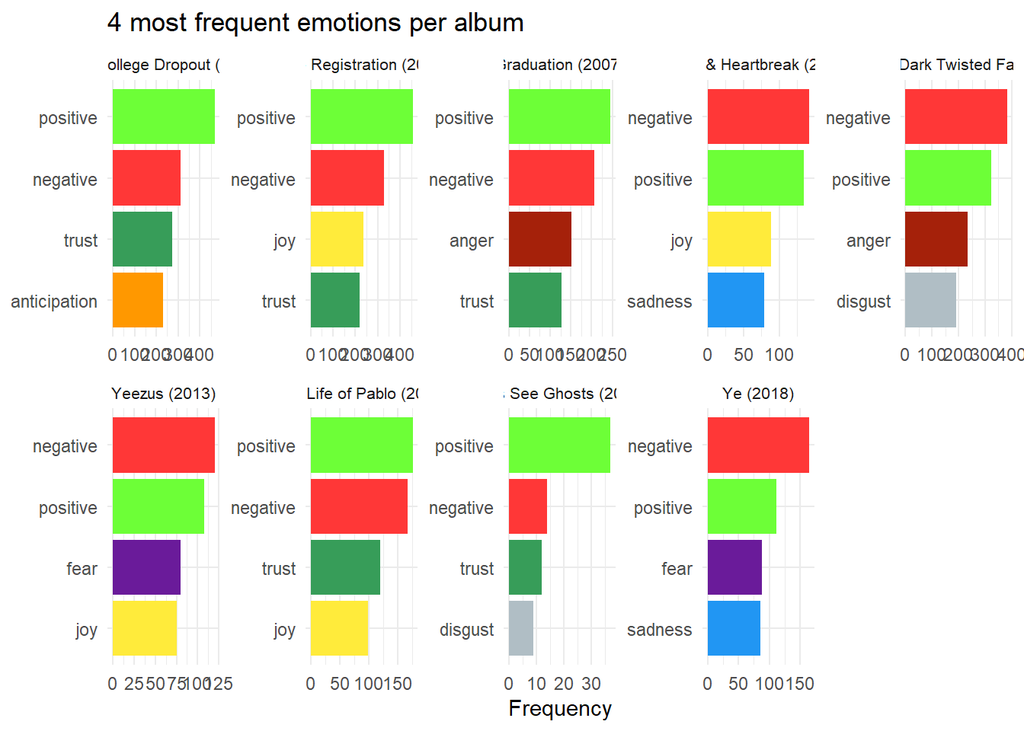

```r
sentiment_colors <- c(
  anger = "#a5210a",
  anticipation = "#FF9800",
  disgust = "#B0BEC5",
  fear = "#6A1B9A",
  joy = "#FFEB3B",
  sadness = "#2196F3",
  surprise = "#FC379f",
  trust = "#379d59",
  negative = "#ff3737",
  positive = "#6dff37"
)

kanye_nrc %>%
  group_by(album, release_year, sentiment) %>%
  count() %>%  # Count how many times each emotion appears in each album
  group_by(album) %>%
  slice_max(n, n = 4) %>%  # Keep the top 4 most frequent emotions per album
  # Create a rank variable for ordering
  mutate(sentiment_rank = rank(-n)) %>%
  ungroup() %>%
  mutate(
    album = factor(album, levels = album_order),  # Ensure chronological album order in facets
    # Create a new variable for plotting that combines sentiment with album
    sentiment_plot = paste(sentiment, album, sep = "___")
  ) %>%
  # Reorder the plotting variable by rank within each album
  mutate(sentiment_plot = reorder(sentiment_plot, -sentiment_rank)) %>%
  ggplot(aes(x = n, y = sentiment_plot, fill = sentiment)) +  # Use sentiment_plot for y, original sentiment for fill
  geom_col(show.legend = FALSE) +  # Bar chart without legend
  facet_wrap(~ album, scales = "free", ncol = 5) +  # Facet by album with independent y-axis
  # Clean up the y-axis labels to show original sentiment names
  scale_y_discrete(labels = function(x) gsub("(.*)___.*", "\\1", x)) +
  scale_fill_manual(values = sentiment_colors) +  # Use your custom sentiment colors
  labs(
    title = "4 most frequent emotions per album",
    x = "Frequency",
    y = NULL
  ) +
  theme_minimal() +
  theme(strip.text = element_text(size = 8))  # Adjust facet title size
```

In this analysis, the most frequent emotions per album of Kanye West are observed. Throughout his career, we observe a predominance of positive and negative sentiments, which is consistent with our previous conclusions. The positive category dominates in the three albums from 2004 to 2007, and then there’s a switch to negative for another three albums (2008-2013), although the frequencies are more balanced.

Additionally, sentiments such as joy and trust regularly stand out in several albums, while anger, fear, disgust and sadness are included in two of the 9 ranks, and anticipation appears in only one. The positive and negative emotions as we have described them do not seem to show a pattern, meaning that, for example, joy can co-occur in the ranking alongside trust, another positive emotion, but also fear or sadness. In sum, all of Kanye’s albums have a somewhat balanced mix of positive and negative emotions.

### b. BING

This section conducts a binary classification between words considered positive and negative.

First, let’s have a first look at the lexicon:

```r
head(bing_lexicon, n = 15)
```

```
## # A tibble: 15 × 2
##    word        sentiment
##    <chr>       <chr>
##  1 2-faces     negative
##  2 abnormal    negative
##  3 abolish     negative
##  4 abominable  negative
##  5 abominably  negative
##  6 abominate   negative
##  7 abomination negative
##  8 abort       negative
##  9 aborted     negative
## 10 aborts      negative
## 11 abound      positive
## 12 abounds     positive
## 13 abrade      negative
## 14 abrasive    negative
## 15 abrupt      negative
```

We should also check if this classification is multilabel as the previous one:

```r
bing_lexicon %>%
  group_by(word) %>%
  summarize(n_labels = n_distinct(sentiment), labels = paste(unique(sentiment), collapse = ", ")) %>%
  filter(n_labels > 1)
```

```
## # A tibble: 3 × 3
##   word        n_labels labels
##   <chr>          <int> <chr>
## 1 envious            2 positive, negative
## 2 enviously          2 positive, negative
## 3 enviousness        2 positive, negative
```

There are only three words, all from the same family, that have the two possible labels attached. Although this is questionable, it doesn’t seem like it will influence our analysis.

Lastly, let’s check for bias in our lexicon:

```r
bing_lexicon %>%
  count(sentiment, sort = TRUE)
```

```
## # A tibble: 2 × 2
##   sentiment     n
##   <chr>     <int>
## 1 negative   4781
## 2 positive   2005
```

The BING lexicon shows a clear skew towards negative sentiment, with more than twice as many terms as for the positive class. There is no “neutral” category.

Now we can move on to visualizing the sentiment of Kanye’s lyrics:

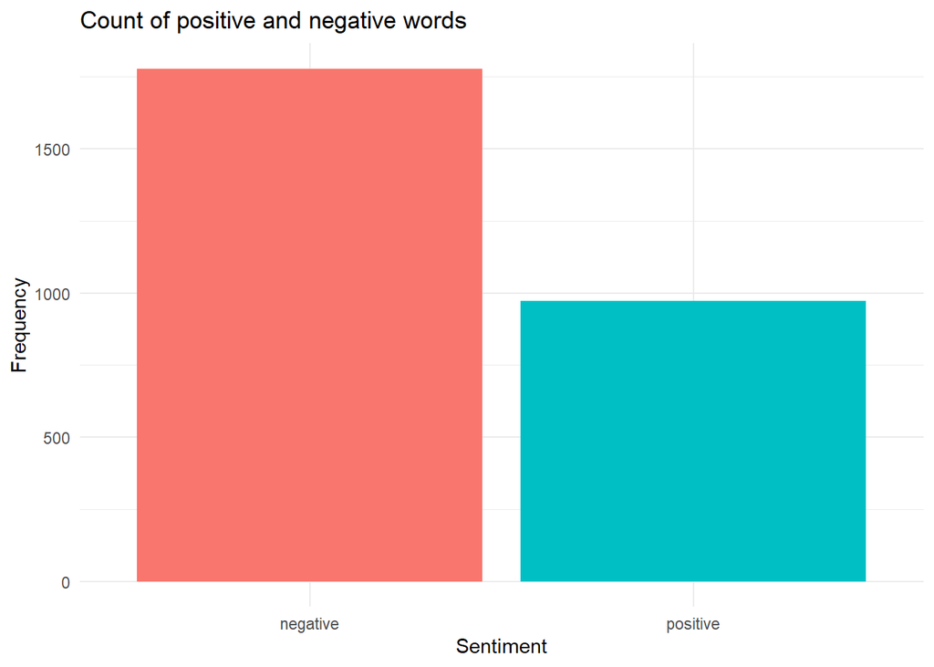

```r
# Count the number of positive and negative words (Bing lexicon)
kanye_bing %>%
  count(sentiment) %>%  # Count total occurrences of each sentiment category (positive/negative)
  ggplot(aes(x = sentiment, y = n, fill = sentiment)) +
  geom_col(show.legend = FALSE) +  # Bar chart without legend
  labs(
    title = "Count of positive and negative words",
    x = "Sentiment",
    y = "Frequency"
  ) +
  theme_minimal()
```

With Bing’s binary classification, it is clear that there is a predominance of words considered negative. This result appears to contradict the previous section’s findings, which might be attributed to the negative skew” that we proved.

Now, let’s examine what this classification looks like by album:

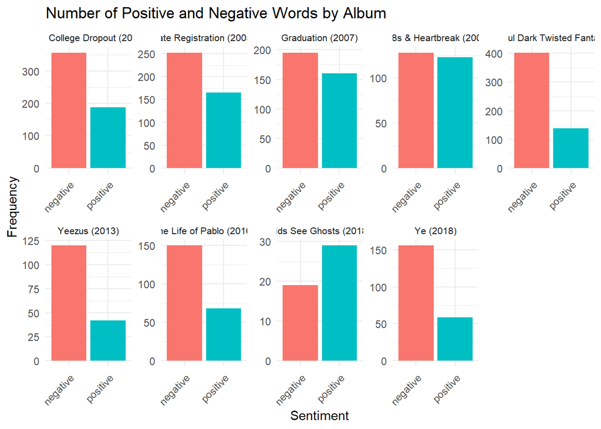

```r
kanye_bing %>%
  count(album, release_year, sentiment) %>%  # Count positive and negative words per album
  mutate(album = factor(album, levels = album_order)) %>%  # Set album order for plotting
  ggplot(aes(x = sentiment, y = n, fill = sentiment)) +
  geom_col(show.legend = FALSE) +  # Bar chart without legend
  facet_wrap(~ album, scales = "free", ncol = 5) +  # Create one panel per album, allowing independent y-scales
  labs(
    title = "Number of Positive and Negative Words by Album",
    x = "Sentiment",
    y = "Frequency"
  ) +
  theme_minimal() +
  theme(
    axis.text.x = element_text(angle = 45, hjust = 1),  # Rotate x-axis labels for readability
    strip.text = element_text(size = 8)  # Adjust size of album titles in facets
  )
```

Negative words are more frequent than positive ones for all of our albums except one: Kids See Ghosts, for which we only have two songs. This is consistent with the first graph of this section but, as that one did, contradicts the conclusions drawn from analysis using the NRC lexicon. It is worth noting that he gap appears to be larger in more recent albums (with the exception of the aforementioned one), suggesting a trend towards imbalance in favour of negative sentiment.

### c. AFINN

In this part, we will analyze the evolution of sentiment using the AFINN lexicon scores (which quantifies the sentiment of words from -5 to 5).

```r
head(afinn_lexicon, n = 15)
```

```
## # A tibble: 15 × 2
##    word       value
##    <chr>      <dbl>
##  1 abandon       -2
##  2 abandoned     -2
##  3 abandons      -2
##  4 abducted      -2
##  5 abduction     -2
##  6 abductions    -2
##  7 abhor         -3
##  8 abhorred      -3
##  9 abhorrent     -3
## 10 abhors        -3
## 11 abilities      2
## 12 ability        2
## 13 aboard         1
## 14 absentee      -1
## 15 absentees     -1
```

We can check how many words are assigned to each value:

```r
afinn_lexicon %>%
  count(value) %>%
  arrange(value)
```

```
## # A tibble: 11 × 2
##    value     n
##    <dbl> <int>
##  1    -5    16
##  2    -4    43
##  3    -3   264
##  4    -2   966
##  5    -1   309
##  6     0     1
##  7     1   208
##  8     2   448
##  9     3   172
## 10     4    45
## 11     5     5
```

We observe that the AFINN lexicon is skewed toward moderately negative values, particularly -2, which appears 966 times. Extreme negative scores (like -4 or -5 and 4 or 5) are relatively rare. Only one word was assigned a value of 0 (neutrality) in this lexicon.

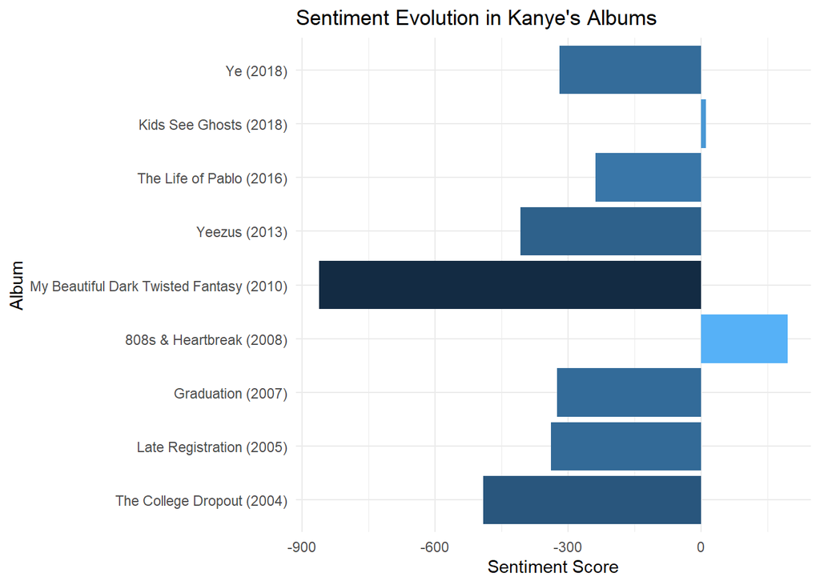

```r
kanye_afinn %>%
  group_by(album, release_year) %>%
  summarise(sentiment_score = sum(value), .groups = "drop") %>%  # Aggregate sentiment scores per album
  mutate(album = factor(album, levels = album_order)) %>%  # Ensure albums are ordered chronologically
  ggplot(aes(x = album, y = sentiment_score, fill = sentiment_score)) +
  geom_col(show.legend = FALSE) +  # Bar chart with fill based on sentiment score, no legend
  coord_flip() +  # Flip coordinates for horizontal bars
  labs(
    title = "Sentiment Evolution in Kanye's Albums",
    x = "Album",
    y = "Sentiment Score"
  ) +
  theme_minimal() +
  theme(strip.text = element_text(size = 8))  # Adjust facet label size (not strictly necessary here)
```

In general, it stands out that the vast majority of albums have a negative score, which seems to confirm what we saw earlier. My Beautiful Dark Twisted Fantasy has the lowest score by far. This album started the trend described in the previous section of a widening gap between positive and negative words. It also showed a preeminence of negative sentiment according to the NRC lexicon.

On the other hand, we see that there is a positive total score in only two cases: - 808 & Heartbreak (2008), which has the highest score. This album had a higher frequency of negative words according to BING, but the difference was the smallest. Positive sentiments also dominated according to NRC. - Kids See Ghosts (2018). This album also revealed a predominance of positive words in the two previous execises.

What’s been done earlier is in absolute terms, which can distort the reality since some albums contain more songs than others. Since the lexicon is skewed towards negative sentiment, lengthier albums have more chances of having negative words, which drags the total score down. Therefore, we will also perform a relative analysis using the average instead of the sum of scores:

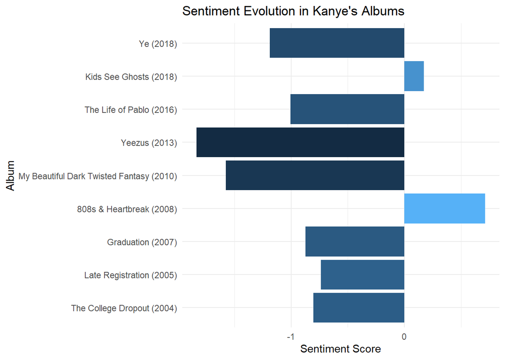

```r
kanye_afinn %>%
  group_by(album, release_year) %>%
  summarise(sentiment_score_avg = mean(value)) %>%  # Calculate average sentiment score per album
  mutate(album = factor(album, levels = album_order)) %>%  # Set the album order for plotting
  ggplot(aes(x = album, y = sentiment_score_avg, fill = sentiment_score_avg)) +
  geom_col(show.legend = FALSE) +  # Bar chart colored by average sentiment
  coord_flip() +  # Flip axes for horizontal bars
  labs(
    title = "Sentiment Evolution in Kanye's Albums",
    x = "Album",
    y = "Sentiment Score"
  ) +
  theme_minimal() +
  theme(strip.text = element_text(size = 8))  # Adjust facet label size (not essential here)
```

Now, the same trend is observed: the majority of albums have a negative average score, with the two previously mentioned albums still maintaining a positive score. However, since these are average scores, some changes are noticeable. 808s & Heartbreak mantains the highest positive average score, and Yeezus becomes the album with the lowest average score, although followed somewhat closely by My Beautiful Dark Twisted Fantasy.

The sentiment analysis of Kanye West’s lyrics reveals a complex emotional landscape throughout his discography. Across his albums, there is a co-appearance of both positive and negative feelings, reflecting the emotional diversity in Kanye’s music. Emotions such as joy, anger, and trust appear regularly, suggesting a broad spectrum of emotional exploration.

It’s also worth mentioning that the style of music Kanye West creates often involves the use of slang, colloquial expressions, and insults, which probably contributes to the negative tone of his lyrics. This will be further explored in the following section.

# 2. Insult Analysis

To analyze this, we will use the **Luis von Ahn List (LDNOOBW)**, which is a database of offensive words in English. It includes insults and slang commonly used in hip-hop. This list is publicly available on GitHub.

What we will do is first examine the relative frequency of insults by album to enable comparison across Kanye’s discography. Then, we will conduct an AFINN sentiment analysis to determine whether albums with a higher proportion of insults tend to have more negative sentiment scores.

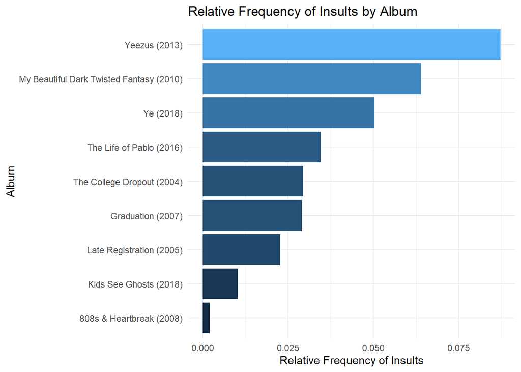

```r
# First, we obtain the list of insults from GitHub:
url <- "https://raw.githubusercontent.com/LDNOOBW/List-of-Dirty-Naughty-Obscene-and-Otherwise-Bad-Words/master/en"
bad_words_vonahn <- readLines(url)  # Load the list of offensive words from the URL

# Then, we calculate the total number of words per album
total_words_by_album <- kanye_filtered %>%
  group_by(album) %>%
  summarise(total_words = n())  # Total word count per album

# Filter the lyrics to keep only words that match the list of offensive terms
kanye_offensive <- kanye_filtered %>%
  filter(word %in% bad_words_vonahn)

# Count number of insults per album and compute relative frequency
insults_by_album <- kanye_offensive %>%
  group_by(album) %>%
  summarise(insult_count = n()) |>  # Count how many offensive words per album
  left_join(total_words_by_album, by = "album") |>  # Merge with total word counts
  mutate(relative_insult_freq = insult_count / total_words)  # Compute proportion of offensive words

# Then, the visualization:
ggplot(insults_by_album, aes(x = reorder(album, relative_insult_freq), y = relative_insult_freq, fill = relative_insult_freq)) +
  geom_col(show.legend = FALSE) +  # Horizontal bar chart
  coord_flip() +  # Flip axes to improve readability
  labs(
    title = "Relative Frequency of Insults by Album",
    x = "Album",
    y = "Relative Frequency of Insults"
  ) +
  theme_minimal()
```

As can be seen, the albums Yeezus (2013) and My Beautiful Dark Twisted Fantasy (2010), which had the lowest sentiment scores in the previous AFINN analysis, also stand out in terms of the highest frequency of insults. Similarly, the albums with positive sentiment scores appear to be the ones with the least number of insults.

For a deeper analysis, we will cross the number of insults with the AFINN sentiment score to see if albums with more insults tend to have more negative sentiment.

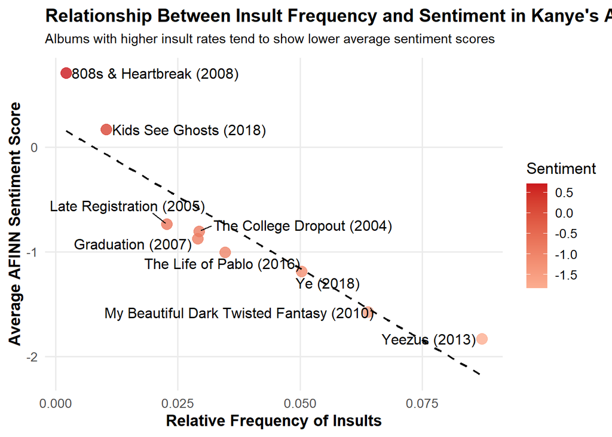

```r
# First, we get the average sentiment scores per album using AFINN
sentiment_by_album <- kanye_afinn %>%
  group_by(album) %>%
  summarise(sentiment_score_avg = mean(value))  # Average sentiment score per album

# Join the sentiment scores to the existing dataframe with insult frequencies
insults_by_album <- insults_by_album |>
  left_join(sentiment_by_album, by = "album")

# Relationship between relative insult frequency and average sentiment score
ggplot(insults_by_album, aes(x = relative_insult_freq, y = sentiment_score_avg, label = album)) +
  geom_point(aes(color = sentiment_score_avg), size = 4, alpha = 0.8) +  # Color gradient by sentiment
  geom_smooth(method = "lm", se = FALSE, color = "black", linetype = "dashed", size = 0.8) +  # Trend line
  ggrepel::geom_text_repel(size = 4.2, max.overlaps = 15) +  # Prevent overlapping text labels
  scale_color_gradient(low = "#fcae91", high = "#cb181d") +  # Warm color gradient for sentiment
  labs(
    title = "Relationship Between Insult Frequency and Sentiment in Kanye's Albums",
    subtitle = "Albums with higher insult rates tend to show lower average sentiment scores",
    x = "Relative Frequency of Insults",
    y = "Average AFINN Sentiment Score",
    color = "Sentiment"
  ) +
  theme_minimal(base_size = 13) +
  theme(
    plot.title = element_text(face = "bold", size = 15),
    plot.subtitle = element_text(size = 11, margin = margin(b = 10)),
    axis.title = element_text(face = "bold"),
    panel.grid.minor = element_blank()
  )
```

```r
# Finally, calculate the correlation coefficient between insult frequency and sentiment
correlation_result <- cor(insults_by_album$relative_insult_freq, insults_by_album$sentiment_score_avg)
correlation_result
```

```
## [1] -0.9188702
```

This graph and the correlation confirm this trend, meaning that albums with a higher number of swear words generally have lower, more negative sentiment scores.

```r
range(insults_by_album$relative_insult_freq)
```

```
## [1] 0.002107482 0.087209302
```

```r
mean(insults_by_album$relative_insult_freq)
```

```
## [1] 0.03663319
```

The relative frequency of swear words ranges from 0.002 to 0.087. On average, Kanye’s lyrics contain less than 4 swear words for every 100 words.

Lastly, we’re going to visualize the most common insults or bad words in Kanye’s lyrics in a wordcloud. For this purpose, we must first lemmatize the words in our dataset, so that their variations (plurals, verb forms, etc.) are not considered as different words.

```r
kanye_offensive <- kanye_offensive |>
  mutate(
    # word_stem = SnowballC::wordStem(word),  # (Optional) stemming: reduces words to root form (commented out)
    word_lemma = textstem::lemmatize_words(word)  # Lemmatization: converts words to their base dictionary form
  )
```

Now, we can check how many unique words we have and how many unique lemmas were created:

```r
# Summarise offensive words: total, unique surface forms, and unique lemmas
kanye_offensive |>
  summarise(
    total_words = n(),  # Total number of offensive word tokens
    unique_words = n_distinct(word),  # Number of unique offensive word forms
    unique_lemmas = n_distinct(word_lemma)  # Number of unique lemmatized forms
  )
```

```
## # A tibble: 1 × 3
##   total_words unique_words unique_lemmas
##         <int>        <int>         <int>
## 1         652           36            33
```

```r
# View all unique lemmatized offensive words
unique(kanye_offensive$word_lemma)
```

```
##  [1] "ass"          "fuckin"       "fuck"         "shit"         "suck"
##  [6] "nigga"        "titty"        "bitch"        "pussy"        "threesome"
## [11] "titties"      "cum"          "sex"          "dick"         "motherfucker"
## [16] "coon"         "bullshit"     "spunk"        "asshole"      "rape"
## [21] "porn"         "anal"         "gangbang"     "sexy"         "butt"
## [26] "porno"        "vagina"       "bastard"      "apeshit"      "poof"
## [31] "snatch"       "cock"         "skeet"
```

We have 36 words and 33 unique lemmas, which means that only 3 words were actually replaced by their canonical form through lemmatization.

We can run a check to see what lemmas were created. We observe that some words weren’t correctly lemmatized, this is possibly because insults and swearwords do not appear in the dictionaries. We can manually assign these words to the most suitable lemma:

```r
# Manually correct specific lemmas that were not properly lemmatized
kanye_offensive <- kanye_offensive %>%
  mutate(
    word_lemma = case_when(
      word == "titties" ~ "titty",     # Normalize plural slang form
      word == "fuckin"  ~ "fucking",   # Restore informal contraction to full form
      TRUE              ~ word_lemma   # Keep existing lemma otherwise
    )
  )
```

The last step is to plot the wordcloud:

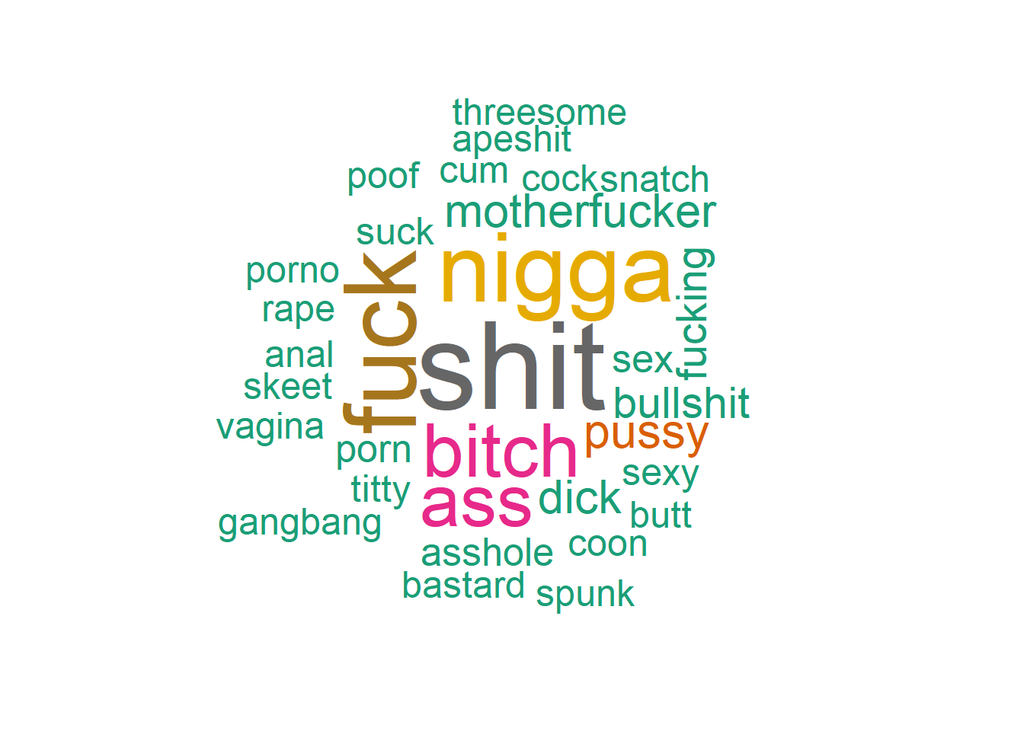

```r
# Count the frequency of lemmatized offensive words
insult_word_counts <- kanye_offensive %>%
  count(word_lemma, sort = TRUE)  # Count and sort by frequency


# Create a word cloud for the most common offensive terms
set.seed(123)  # For reproducibility of word placement
wordcloud(
  words = insult_word_counts$word_lemma,
  freq = insult_word_counts$n,
  min.freq = 1, # Include all words that appear at least once
  max.words = 100, # Limit to top 100 words
  scale = c(5, 1.5),
  colors = brewer.pal(8, "Dark2"),
  random.order = FALSE ) # Most frequent words centered
```

The most common insults in Kanye West’s lyrics are “shit”, “nigga”, “fuck”, “ass”, “bitch”, “pussy”, “motherfucker” and “dick”, which we believe is a common trend in American hip-hop by male artists.

TF-IDF might serve us to analyze the representativeness of offensive words, although we anticipate that the scores will be fairly low, since we know that there is a short list of swear words which are likely to appear several times across all of Kanye’s albums.

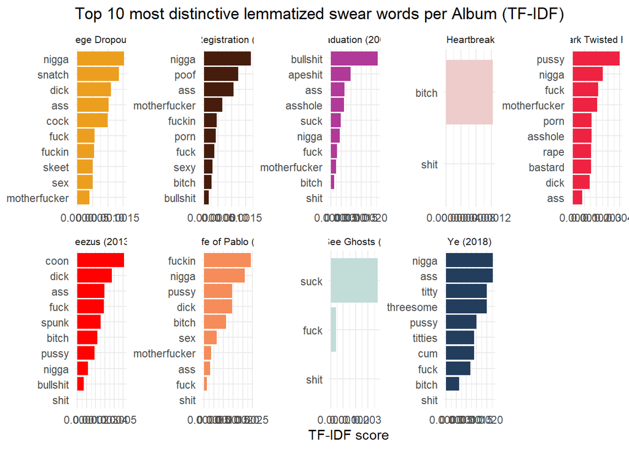

```r
# Lemmatize all words before calculating TF-IDF
kanye_filtered <- kanye_filtered |>
  mutate(word_lemma = textstem::lemmatize_words(word))

# Calculate TF-IDF scores for all lemmatized words across albums
tfidf_all <- kanye_filtered %>%
  count(album, word_lemma, sort = TRUE) %>%  # Count word occurrences per album
  bind_tf_idf(word_lemma, album, n) %>%  # Compute TF-IDF: importance of a word within an album
  arrange(desc(tf_idf))  # Sort by highest TF-IDF score

# Filter only the offensive words from the TF-IDF results
tfidf_offensive <- tfidf_all %>%
  filter(word_lemma %in% bad_words_vonahn)

# Visualize the top 10 most distinctive offensive words per album using TF-IDF
tfidf_offensive %>%
  group_by(album) %>%
  slice_max(tf_idf, n = 10) %>%  # Get top 10 offensive words by TF-IDF per album
  ungroup() %>%
  mutate(
    album = factor(album, levels = album_order),  # Ensure correct album order
    word_lemma = reorder_within(word_lemma, tf_idf, album)  # Reorder for facet display
  ) %>%
  ggplot(aes(tf_idf, word_lemma, fill = album)) +
  geom_col(show.legend = FALSE) +  # Bar plot without legend
  facet_wrap(~ album, scales = "free", ncol = 5) +  # One panel per album, independent y-axis
  scale_y_reordered() +  # Fix label ordering
  scale_fill_manual(values = kanye_colors) +  # Use album-specific color palette
  labs(
    title = "Top 10 most distinctive lemmatized swear words per Album (TF-IDF)",
    x = "TF-IDF score",
    y = NULL
  ) +
  theme_minimal() +
  theme(strip.text = element_text(size = 8))  # Adjust size of album labels in facets
```

As we were expecting, the scores are low and most curse words with the top TF-IDF scores are repeated across the albums. This makes sense because swear words are usually not that descriptive or meaningful, but rather complements, attached to other words for emphasis, to express aggressiveness, etc. Due to their nature and the relatively low number of distinct swear words found in Kanye’s lyrics, many of them are common to all of his albums and not distinctive of any of them.

# 3. Word co-occurences

For this exercise, we will analyze the word co-occurences in Kanye’s songs at the line level.

The first thing we need to do is separate the lines from our original dataset, which we had called “kanye_west”. We can split the text by the line breaks, which are signalled as “\n”:

```r
# Split lyrics into individual lines for line-by-line analysis
lines_df <- kanye_west %>%
  mutate(line = str_split(text, pattern = "\n")) %>%  # Split lyrics by newline character
  unnest(line) %>%  # Expand the list-column into one row per line
  filter(str_detect(line, "\\w")) |>  # Remove empty or purely whitespace lines
  mutate(line_id = row_number())  # Assign a unique ID to each line
```

We can now tokenize words keeping the line id, and then count how many times words co-appear in the same line, using the pairwise_count function:

```r
# Tokenize lines into individual words and remove stop words
words_by_line <- lines_df %>%
  unnest_tokens(word, line) |>  # Tokenize the text column line-by-line
  anti_join(stop_words)  # Remove common stop words

# Calculate pairwise word co-occurrence within each line
word_pairs <- words_by_line %>%
  pairwise_count(item = word, feature = line_id, sort = TRUE)  # Count how often pairs of words appear in the same line
```

## a. Women referal Network

It might be interesting to analyze, for example, what words appear together with words referring to women in Kanye’s lyrics:

```r
# Filter the word co-occurrence network for selected target words and higher frequency
word_pairs %>%
  filter(
    item1 %in% c("girl", "bitch", "baby", "girls", "bitches"),  # Focus on selected gender-related or recurring terms
    n > 2  # Keep only word pairs that co-occur more than twice
  ) %>%
  arrange(desc(n))  # Sort by descending co-occurrence frequency
```

```
## # A tibble: 62 × 3
##    item1 item2       n
##    <chr> <chr>   <dbl>
##  1 girl  leave      36
##  2 girl  gotta      34
##  3 girl  head       32
##  4 girl  love       12
##  5 girls hot        11
##  6 girls drunk      11
##  7 girl  mistake    10
##  8 bitch bad         9
##  9 baby  outta       9
## 10 baby  lights      8
## # ℹ 52 more rows
```

The table above shows the most frequent co-occurring words with terms such as “girl”, “bitch”, or “baby” in Kanye’s lyrics. This kind of analysis can give us insight into the tone, context, and narrative style Kanye uses when referring to women throughout his discography. We could visualize these relationships using a network graph, highlighting the central words and their strongest connections:

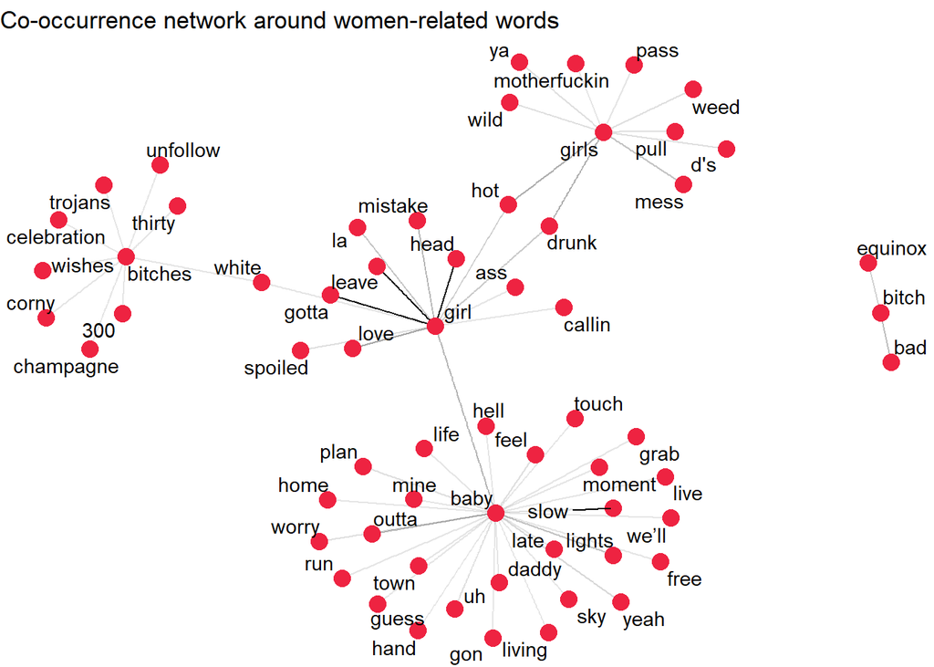

```r
# Visualize co-occurrence network for selected "women-related" words
word_pairs %>%
  filter(
    item1 %in% c("girl", "bitch", "baby", "girls", "bitches"),  # Focus on central terms of interest
    n >= 3  # Only include word pairs that co-occur in at least 3 lines
  ) %>%
  graph_from_data_frame() %>%  # Convert to igraph object
  ggraph(layout = "fr") +  # Use Fruchterman-Reingold layout for force-directed graph
  geom_edge_link(aes(edge_alpha = n), show.legend = FALSE) +  # Edge transparency reflects frequency
  geom_node_point(color = "#ee2341", size = 4) +  # Use bold red for nodes (matches MBDTF color)
  geom_node_text(aes(label = name), repel = TRUE) +  # Add labels and prevent overlapping
  theme_void() +  # Remove background and axes
  labs(title = "Co-occurrence network around women-related words")
```

What stands out from this network is that many words that appear together with plural terms (“girls” and “bitches”) seem to be similar in nature, denoting topics like party and celebration (“celebration”, “mess”, “wild”), sometimes involving the presence of alcohol and drugs (“champagne”, “weed”, “drunk”).

The world “girl” is particularly linked to the words “head”, “mistake”, “gotta” and “leave”. This might point at some kind of problematic relationship between Kanye and one or more girls, where he expresses the desire or intention to turn away from her or them. Other words that co-occur with “girl” carry varied meanings, some positive (“love”), some related to physical appearance (“hot”, “ass”), and some probably used in a pejorative way (“spoiled”, “white”).

Lastly, words that share lines with “baby” seem to depart from the previous terms, reflecting a more intimate relationship with the subject: “touch”, “life”, “feel”, “hand”, “home”, “mine”, “plan”, etc. This makes sense considering that baby is used frequently as an affectionate nickname, while “bitch” is a slur against women and “girl” is, in principle, a neutral appellative. We have considered the possibility that Kanye uses “baby” in a different sense (namely to refer to a child), but we believe that the likelihood of this is low.

## b. Self-Reflection Network in Kanye’s Lyrics

To explore how Kanye reflects on himself in his lyrics, we conducted an analysis of word co-occurrences around the terms “I”, “me”, and “my”. These words serve as markers of self-representation in the lyrics, and by analyzing which words tend to co-occur with them, we can gain insight into Kanye’s self-perception, ego, vulnerabilities, and other recurring themes in his music.

```r
# Define "important" pronouns and exclude them from stop word removal
important_words <- c("i", "me", "my")

# Create a custom stop words list that retains first-person pronouns
custom_stop_words <- stop_words %>%
  filter(!word %in% important_words)

# Tokenize lyrics into words per line, removing custom stop words
words_by_line2 <- lines_df %>% # we retrieve this data frame that wasn't changed by tokenization or stopword removal
  unnest_tokens(word, line) %>%
  anti_join(custom_stop_words)

# Compute co-occurrence counts of words within lines
word_pairs2 <- words_by_line2 %>%
  pairwise_count(item = word, feature = line_id, sort = TRUE)

# Focus on frequent co-occurrences involving self-referential terms
word_pairs2 %>%
  filter(
    item1 %in% c("i", "me", "my", "kanye"),  # Focus on words linked to identity
    n >= 10  # Only keep strong associations
  ) %>%
  arrange(desc(n))  # Sort by frequency
```

```
## # A tibble: 108 × 3
##    item1 item2     n
##    <chr> <chr> <dbl>
##  1 i     my      211
##  2 my    i       211
##  3 i     me      157
##  4 me    i       157
##  5 i     feel     95
##  6 i     love     67
##  7 i     gotta    65
##  8 me    my       62
##  9 my    me       62
## 10 i     yeah     57
## # ℹ 98 more rows
```

Next, we visualize the co-occurrences in a network graph. In this graph, the central words are “I”, “me”, and “my”, and we look at how these self-referential terms connect to other words. This network visualization helps us understand which words or themes are most closely linked to Kanye’s self-representation.

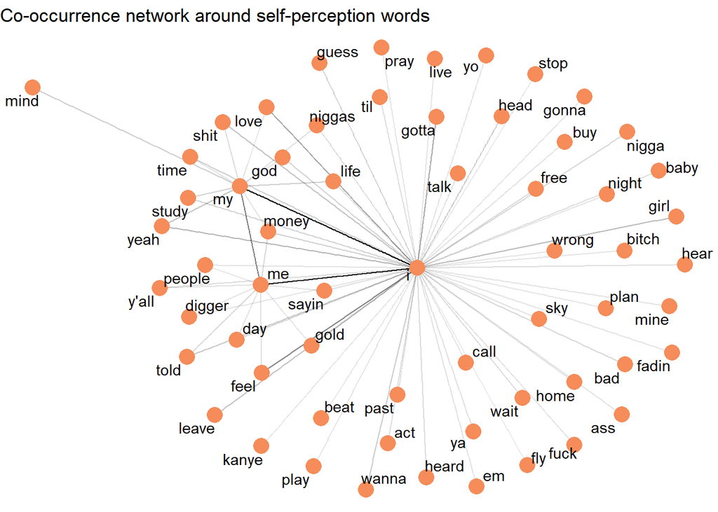

```r
# Visualize co-occurrence network for self-perception words
word_pairs2 %>%
  filter(
    item1 %in% c("i", "me", "my"),  # Focus on first-person pronouns
    n >= 12  # Only include strong co-occurrences
  ) %>%
  graph_from_data_frame() %>%  # Convert to igraph object
  ggraph(layout = "fr") +  # Force-directed layout for natural node positioning
  geom_edge_link(aes(edge_alpha = n), show.legend = FALSE) +  # Edges with transparency based on co-occurrence strength
  geom_node_point(color = "#f58c59", size = 5) +  # Use Pablo-inspired color for nodes
  geom_node_text(aes(label = name), repel = TRUE) +  # Prevent label overlap
  theme_void() +  # Remove background and axes for a clean network graph
  labs(title = "Co-occurrence network around self-perception words")
```

Taken together, this meshing structure reveals that Kanye’s “lyrical self” is not monolithic: it oscillates between self-doubt, ambition, and self-assertion. The density of these connections confirms that self-reflection is a common thread throughout his discography, and his way of flirting between exposing his fears and celebrating his accomplishments through nightlife reinforces the message of his songs.

## c. Religion Network

We then explore the specific co-occurrence network of terms related to religion and the sacred. We selected words such as “God”, “Jesus”, “pray”, etc. and constructed a graph that allows us to identify how these concepts dialogue with each other and with other topics (faith, redemption, guilt). This analysis facilitates understanding the density and context in which Kanye incorporates religious references in his lyrics.

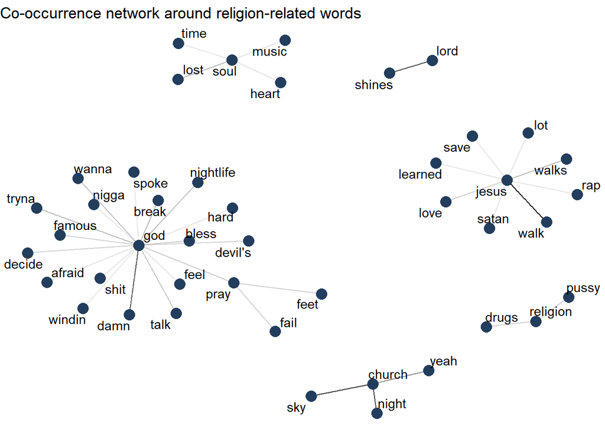

```r
# Define a list of religion-related keywords
religious_words <- c("god", "jesus", "lord", "faith", "pray", "prayer", "prayers", "church", "gospel", "heaven", "blessings", "soul", "bless", "hallelujah", "blessed", "religious", "religion", "believer")

# Filter for strong co-occurrences involving religious terms and plot the network
word_pairs %>%
  filter(
    item1 %in% religious_words,  # Focus on selected religious terms
    n >= 2  # Keep only links with at least 2 co-occurrences
  ) %>%
  graph_from_data_frame() %>%  # Convert to igraph object
  ggraph(layout = "fr") +  # Force-directed layout
  geom_edge_link(aes(edge_alpha = n), show.legend = FALSE) +  # Edge transparency reflects frequency
  geom_node_point(color = "#233d5d", size = 4) +  # Node color inspired by "Ye" album palette
  geom_node_text(aes(label = name), repel = TRUE) +  # Add node labels with overlap protection
  theme_void() +  # Minimalist graph styling
  labs(title = "Co-occurrence network around religion-related words")
```

The “Religion Network” shows that ‘God’ and “Jesus” act as authentic centers of gravity in the graph. In general, we observe an ambivalent tone in Kanye’s lyrics relating to religious words. While words linked to “Jesus” make more contextual sense (“love”, “save”), the term “God” seems to be used in a broader sense (the stronger link with it forms the expression “god damn”, which probably carries no real religious meaning). In the same way, we do observe some unions of terms that make us understand that the use of religiosity can sometimes border on the profane in his lyrics. For example, the word “nightlife” appears in the “God” cluster; the word “religion” is linked to the terms “drugs” and “pussy” in Kanye’s lyrics. Another one of the chosen words, “soul”, is probably not really used in the songs analyzed here in a religious sense. The two words that are the core to the most important clusters, “God” and “Jesus”, appear together with “Devil’s” and “Satan” respectively, which reveals Kanye’s tension or duality when discussing religion or faith. However, we know that the topic of religion and the relationship to God is further explored in his later work.

## d. Money Network

[figure not shown]

```r
# Define a list of money-related keywords
money_words <- c("money", "cash", "rich", "wealth", "dollars", "gold",
                 "rolls", "bills", "chains", "luxury", "spend", "buy", "pay",
                 "cost")

# Filter for co-occurrences involving money-related words and visualize the network
word_pairs %>%
  filter(
    item1 %in% money_words,  # Focus on economic/luxury-related terms
    n >= 2  # Keep only meaningful links
  ) %>%
  graph_from_data_frame() %>%  # Convert to igraph object
  ggraph(layout = "fr") +  # Force-directed layout
  geom_edge_link(aes(edge_alpha = n), show.legend = FALSE) +  # Edge transparency by co-occurrence strength
  geom_node_point(color = "#ec9f1f", size = 4) +  # Use color inspired by "The College Dropout"
  geom_node_text(aes(label = name), repel = TRUE) +  # Add word labels with collision avoidance
  theme_void() +  # Clean, minimal style
  labs(title = "Co-occurrence network around money-related words")
```

The node “money” clearly stands out as the most connected, serving as a direct bridge to multiple concepts associated with wealth. Around it gravitate terms such as “pay”, ‘buy’ and “gold”, which form a primary core of material exaltation. The words that appear in these clusters are indeed the most materialistic of the graph, referring to very particular, practical uses of money (weed, smoke, spaceship, insured, lipo). Other words are joined with “money” to create expressions of abundance (pile, stack).

On the other hand, we see relationships at the money level that are circumscribed to specific songs, as for example with the song “Gold Digger” in which he talks about how a woman tries to get money from her lovers for aesthetic operations, luxuries, etc. This explains certain relationships that we see in the center of the “money” node.

Interconnected with this main group, thematic clusters appear that combine deeper or conflicting reflections on the subject of money: for example, nodes such as “power” are linked to “wealth” and ‘nobility’, suggesting reflections on how money is power for the artist. The cluster around “rich” is hard to decode: words like “cotton”, “slave” or “fabric” emerge, perhaps alluding to slave labor or pointing to how people (or himself) are enslaved by money.

Overall, this network shows that the theme of money in Kanye West is not merely decorative: it works in a direct way to narrate everything that money can give you both on a more mundane level and from the perspective of power. However, Kanye is not always the subject of these expressions, but he also discusses how other subjects access to and use their money.

# Final Considerations

Despite these achievements, our study encountered several methodological challenges worth noting. Firstly, the corpus was limited to Kanye’s solo albums, excluding collaborations, promotional singles, and recent works after 2018. Including these additional texts in future research would enhance the temporal breadth and stylistic understanding of Kanye’s evolving artistic direction. Furthermore, employing techniques such as topic modeling (LDA, NMF) or phrase embeddings could further illuminate latent thematic structures not immediately evident through traditional frequency analysis.

Secondly, inconsistencies in lemmatization during the text processing phase sometimes resulted in artificially fragmented terms (e.g., “run” vs. “running” vs. “ran”). Applying consistent lemmatization or stemming prior to frequency and TF-IDF analysis, as well as word co-occurence, would likely improve our lexical precision, ensuring that morphological variations are grouped appropriately and thus reflecting a more accurate portrayal of Kanye’s lyrical richness.

Thirdly, our sentiment analysis relied on lexicons such as Bing, NRC, and AFINN, which have inherent limitations when analyzing lyrics rich in irony, double meanings, and specific hip-hop slang. To address these nuances more effectively, future studies should integrate other advanced contextual language models like BERT or RoBERTa, capable of capturing deeper semantic and emotional subtleties. Moreover, complementing our quantitative insights with qualitative analysis (such as reviews, interviews, audience reception, and visual content) would ground our findings in a richer socio-cultural context. This scope should ensure that our conclusions go beyond statistical descriptions, allowing a deeper understanding of how Kanye’s lyrics resonate emotionally and culturally with diverse audiences over time.

In conclusion, this project demonstrates how text mining can illuminate critical dimensions of artistic expression. The techniques employed provided us with greater knowledge and better understanding of Kanye West’s work and career. Nevertheless, as we have tried to make clear, what has been done here is only a fraction of all the possibilities offered by quantitative and qualitative methodologies, and does not pretend to give a complete picture, but rather an exploration, of the artist’s personal and musical evolution.